# Lecture 5: More SVD

One of the most far-reaching ideas from this section is the use of the SVD for dimension reduction. We're all swimming in data, and the SVD provides a way to reduce large data sets to its most essential components.

Here we load data about all the votes made in the U.S. House of Representatives during the 111th Congress.

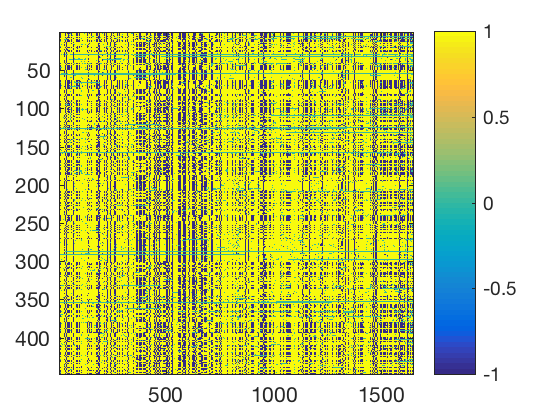

```matlab
load hou111kh
imagesc(A), colorbar
```

The rows represent voters, the columns represent bills or other vote items, and the color shows the vote: yellow is 'yea', blue is 'nay', and green is 'no vote'. Each row is the fingerprint of a particular representative. As you can easily see, there is a great deal of dependence among those rows, indicating party affiliation.

Extracting meaning from the data is a bit cleaner if we use the difference of each vote from the voter's average vote.

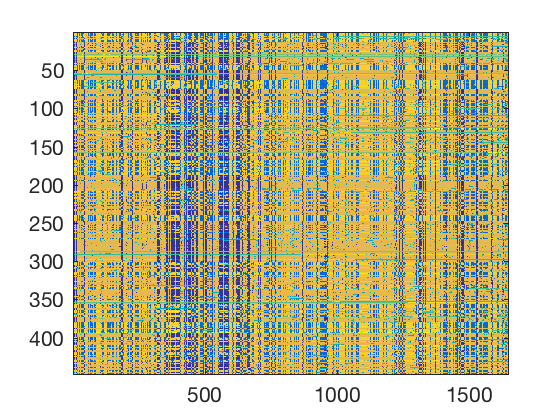

```matlab
mu = mean(A,2);
A = bsxfun(@minus,A,mu);  % subtract each voter's average from all votes
imagesc(A)
```

We're going to use the SVD to find principal directions in the data. First we transpose the matrix so that it's got a tall, thin shape like we're used to.

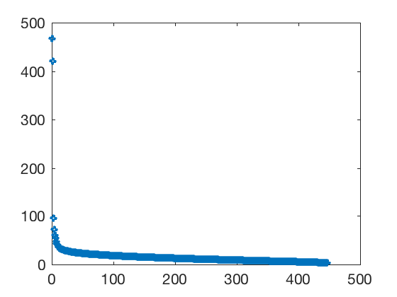

```matlab
B = A';
[U,S,V] = svd(B,0);
sigma = diag(S);
plot(sigma,'o','markersize',3)
```

Clearly there's a lot more information in the first two singular directions than in all of the others. We project each voter's record into those two directions.

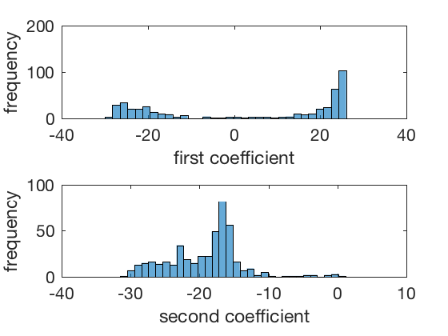

```matlab
x1 = U(:,1)'*B;   x2 = U(:,2)'*B;
subplot(211), histogram(x1,32)
xlabel('first coefficient'), ylabel('frequency')
subplot(212), histogram(x2,32)
xlabel('second coefficient'), ylabel('frequency')
```

The first coefficient shows clear polarity, with most voters having a large-magnitude coefficient. Political scientists call this quantity *partisanship*. The second is a little less obvious, but it is commonly called *bipartisanship*. It shows how willing a voter is to go against his or her party. The 21st century has seen some of the least bipartisan Congresses in history.

We can now represent each voter by these two coordinates. A scatter plot dramatically illustrates the nature of the voting. We also use the known party affiliation to color each voter.

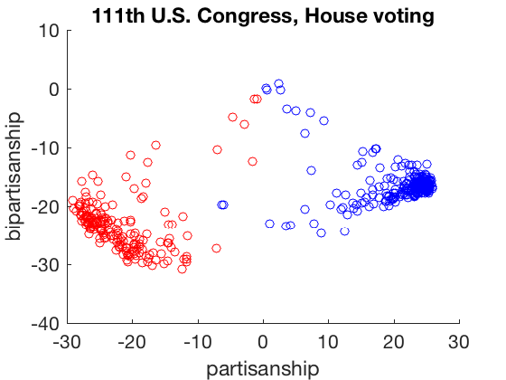

```matlab
c = zeros(size(A,1),3);
c(party==1,3) = 1;  % blue
c(party==2,1) = 1;  % red
scatter(x1,x2,20,c)
xlabel('partisanship'), ylabel('bipartisanship')
title('111th U.S. Congress, House voting')
```

It's clear as day that this Congress was very politcally polarized. Note that those with the higher (more positive) bipartisanship scores are the ones willing to meet in the middle.